# Project1

Brian

2024-09-25

# **Introduction**

Today the data set I will be using was retrieved from the online website github. Within the online description, it can be found that that dataset was originally downloaded from a public excel sheet labeling the Rolling Stone top 500 albums from 2020. The dataset was thing cleaned and restructured, consisting of unifying syntax and replacing empty cells. The dataset consists of variables such as genre, year released, album names, and the ranking themselves. With that being said, I will be using the peak billboard position as my overall outcome variable of interest and alongside it investigating genre, year released, and member count as predictor variables.

[figure not shown]

https://en.wikipedia.org/wiki/Abbey_Road

# **Outcome Variable**

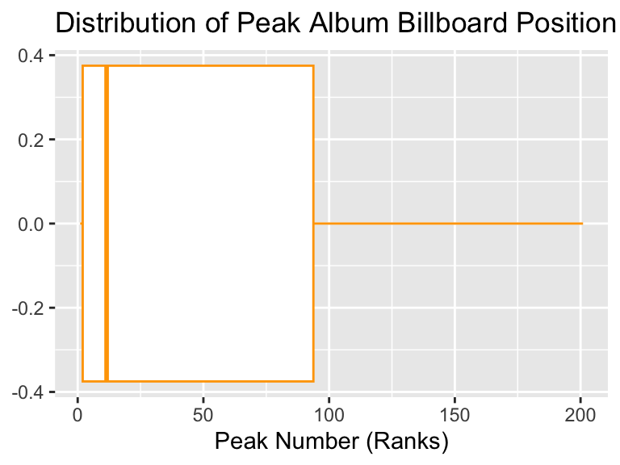

```
## [1]   1   2  12  94 201
```

Shown above is a 5 number analysis of the distribution in album peak billboard ranks within the Rolling Stone’s Top 500 albums of all time. Evaluating this, with a median of 12 and the 1st Quartile being 2 while the 3rd Quartile being 94 , we can confidently say that the graph is skewed to the right.

# **Bivariate Analyses**

## **Year Released Analysis**

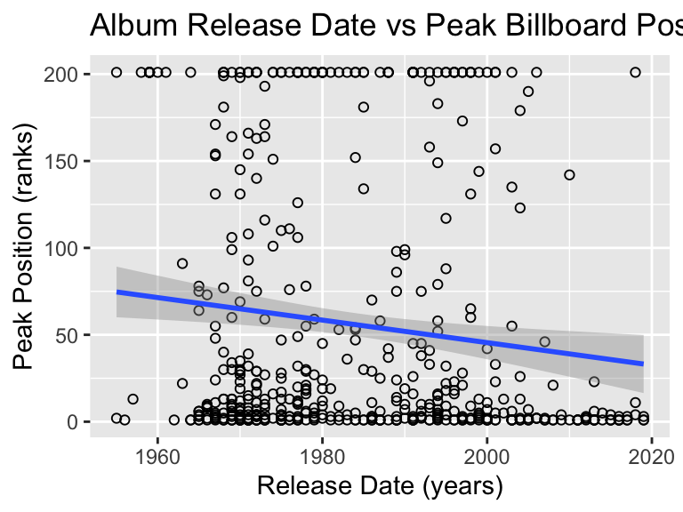

The graph above shows the relation between an album’s official release date in years and their eventual peak billboard rank appearance over the course of their time played to the public.

Seeing that that the correlation coefficient between the release date in years of an album and the peak rank of the album itself is -0.13, the value is extremely far away from -1 and close to 0, meaning that there is a weak correlation between the two variables.

## **Member Count Analysis**

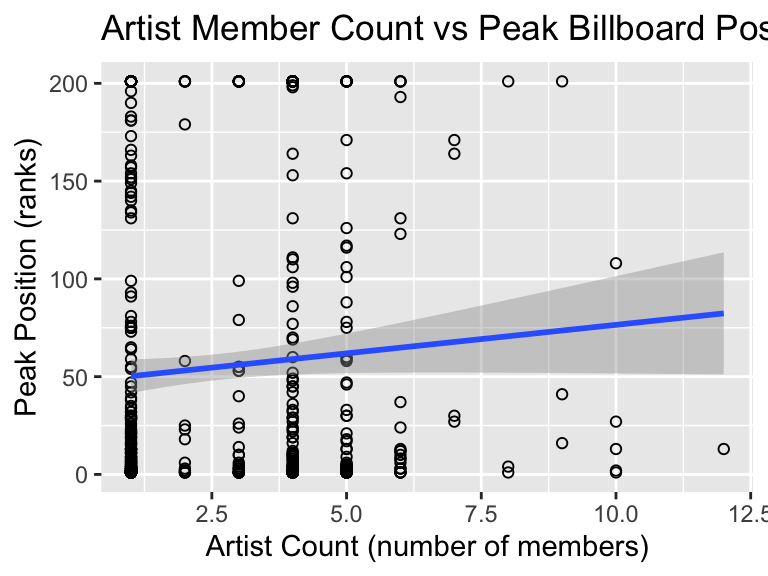

The graph above shows the relation between an album’s artist count in number of me,bers and their eventual peak billboard rank appearance over the course of their time played to the public.

Seeing that that the correlation coefficient between the artist count in number of members and the peak rank of the album itself is 0.08, the value is extremely far away from 1 and close to 0, meaning that there is a weak correlation between the two variables.

In addition, this numerical variable is particularly noticeable because of a slight trend in the overall appearance of the graph. Rather, it can be seen that most of the peak ranks among the top 500 albums dataset are shown to be grouped under artist groups consisting of only 1 or a few members, rather than artists groups consisting of more artists. The link below expands upon this trend and might help explain why this happens.

https://news.fit.edu/campus/is-music-better-in-groups-or-solo-that-depends/

## **Genre Analysis**

[figure not shown]

```
##                                Group.1         x
## 1                             Afrobeat 201.00000
## 2                        Big Band/Jazz 132.00000
## 3                     Blues/Blues Rock  49.78571
## 4                     Blues/Blues ROck   1.00000
## 5  Country/Folk/Country Rock/Folk Rock  45.97500
## 6                           Electronic  66.72727
## 7                           Funk/Disco  37.63158
## 8                      Hard Rock/Metal  26.33333
## 9                          Hip-Hop/Rap  20.43860
## 10              Indie/Alternative Rock  52.57447
## 11                               Latin 125.50000
## 12   Punk/Post-Punk/New Wave/Power Pop 112.03509
## 13                              Reggae 109.80000
## 14         Rock n' Roll/Rhythm & Blues  83.33333
## 15    Singer-Songwriter/Heartland Rock  45.60000
## 16                     Soul/Gospel/R&B  34.75385
```

The chart above shows the different means attached to each genre, representing the distributions in the bar graphs.

The categorical variable that I chose was Genre largely because a lot of time music is ranked based off of meaning and also the representation of certain topics and events happening in the world at the time. Attached is a link that explains the affects of certain genres, largely in relation to the concepts that albums represent, and how that might show their importance to music as a whole. https://carolinianuncg.com/2022/11/01/concept-albums-how-music-and-storytelling-unite/

[figure not shown]

# **Choice Elements**

# **Conclusion**

Performing this report based off of Rolling Stone’s Top 500 Albums of All Time data has allowed me to investigate several variables involving the release and ranking of albums in general. While the numerical variables of album release date and member count were not resolute enough to show a reliable relationship with an albums peak billboard ranking, plotting the categorical variable of genre, showed which genres were correlated with an overall higher peak billboard ranking. Taking this into note, their areas of concern in which in the future can improve the data given such as moving towards investigating how these trends change in general depending on the decade. Ranking the top 500 albums by decade could be an optimal step towards highlighting the shift in mindset from the general mindset surrounding album performance and rankings overall.

References:

https://github.com/rfordatascience/tidytuesday/blob/master/data/2024/2024-05-07/readme.md https://carolinianuncg.com/2022/11/01/concept-albums-how-music-and-storytelling-unite/ https://news.fit.edu/campus/is-music-better-in-groups-or-solo-that-depends/ https://en.wikipedia.org/wiki/Abbey_Road https://pudding.cool/2024/03/greatest-music/